# Introduction

# Profiles

Likelihood profiles are useful to check that you are actually at a global solution and not stuck on a small hill with your back to the mountain. They are also useful for evaluating the infomation content of the data and whether different data sets are telling you different things and you need to ask more questions to determine the truth.

The control slot can be used to produce a profile, i.e. fix a parameter or parameters for a range of values and then find the maximum likelihood by estimating the other parameters.

1D

```r
res = profile(bdHat, which = "r", fixed = c("b0", "p"), cpue, range = c(1.2,
    3))
ggplot(res) + geom_line(aes(r, ll))
```

[output not shown]

1D

```r
ggplot(res, aes(r, k, z = ll))
```

2D

```r
ggplot(res, aes(r, k, z = ll)) + stat_contour(aes(colour = ..level..), size = 1)
```

[output not shown]

likelihood components

```r
ggplot(res, aes(r, k, z = ll)) + stat_contour(aes(colour = ..level..), size = 1)
```

[output not shown]

# Stock status

A main objective of stock assessment is to estimate uncertainly in stock status. This requires estimates of distributions as well as point estimates.

```r
sims = biodyns(`Best Fit` = bd)
```

There are various ways to estimate undercertainty in parameter estimates and quantities derived from them, i.e. use the covariance matrix provided by a maximum likelihood fit, bootstrapping, the jack knife or Bayesian methods such as Monte Carlo Markov Chain,

## Variance/Covariance Matrix

Fitting using maximum likelihood provides the covariance matrix for the parameters. We can use this to conduct a Monte Carlo simulation of the parameter estimates to derive uncertainty in derived quantities.

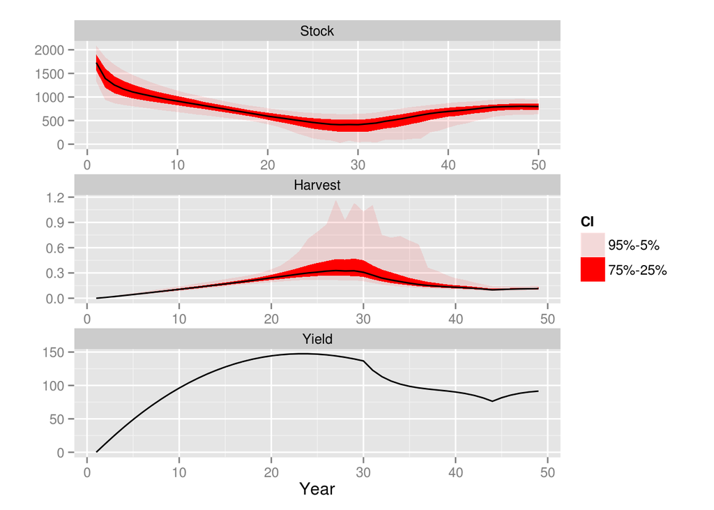

```r
save(bdHat, cpue, file = "/home/laurie/Desktop/bdHat.RData")
sims[["Vcov"]] = mvn(bdHat, 500, nms = c("r", "k"), fwd = TRUE)

plot(sims[["Vcov"]])
```

```r
save(sims, file = "/home/laurie/Desktop/sims.RData")
```

## The Bootstrap

The Bootstrap can be used to simulate CPUE series replicates and the model refitted.

```r
cpueSim = bdHat@diags[, c("year", "hat")]
names(cpueSim)[2] = "data"
cpueSim = as.FLQuant(cpueSim)

# cv(diags['residuals'])

cpueSim = rlnorm(100, log(cpueSim), 0.25)

cpueSim[cpueSim == 0] = NA

plot(sims[["CPUE"]])

sims[["CPUE"]] = fit(propagate(bdHat, 100), cpueSim)
```

## Jack knife

The Jack knife is a relatively quick procedure and so suitable for simulation testing

```r
sims[["Jack Knife"]] = fit(bdHat, jackknife(cpue))
```

The results from the fit can then be used to estimate uncertainty

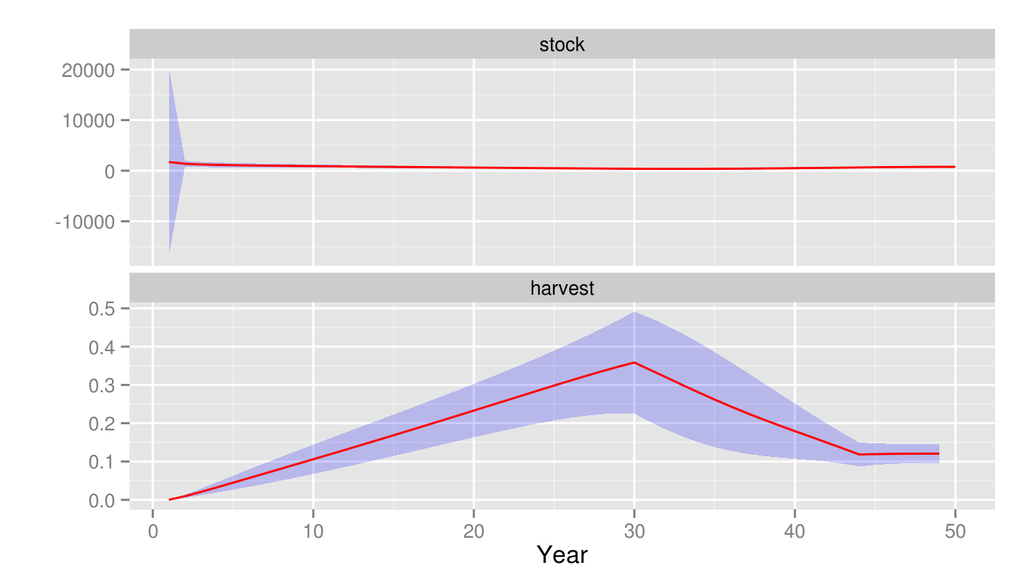

```r
plotJack(sims[["Jack Knife"]], bdHat)
```

## MCMC

Monte Carlo Markov Chain

```r
sims[["MCMC"]] = fit(bdHat, cpue, cmdOps = c("-mcmc 100000, -mcsave 50000"))
```

```
[1] TRUE
```

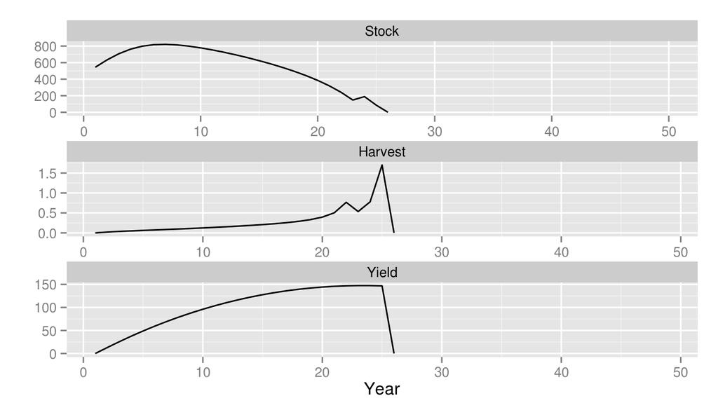

```r
plot(sims[["MCMC"]])
```

Diagnostics need to be run to make sure that the results have actually estimated a stationary distribution.

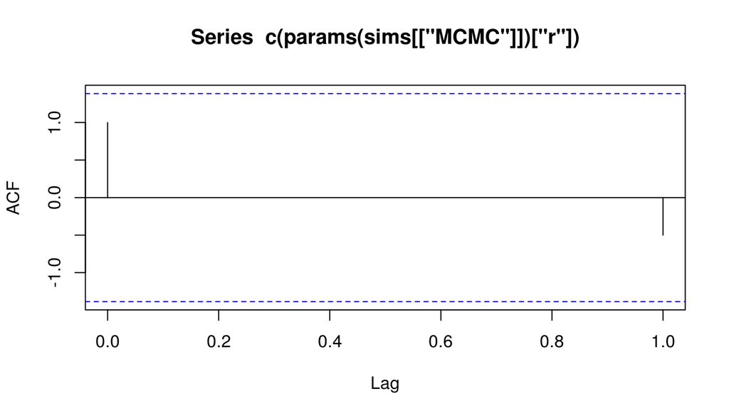

```r
acf(c(params(sims[["MCMC"]])["r"]))
```

# Reference Points

The Precautionary Approach requires stock status to be estimated relative to reference points. The covariance matrix can be used to estimate uncertainty in derived quantities, i.e. those used for management such as $F:F_{MSY}$. These can be found in the mng slot.

```r
head(bdHat@mng)
```

```
An object of class "FLPar"
       var
param   hat        sd
  _r    3.8974e-01 1.0934e-01
  _k    1.1018e+03 1.5788e+02
  _a    1.5586e+00 5.5438e-01
  _p    5.8730e-01 4.4052e-01
  _q[1] 8.9215e-01 1.3392e-01
  _s[1] 1.9488e-01 1.9686e-02
units:  NA
```

The variance matrix is in the mngVcov slot

```r
bdHat@mngVcov
```

These can be used to simulate joint distributions

```r
currentState = bdHat@mng[c("bbmsy", "ffmsy"), "hat", drop = T]
currentStateVar = bdHat@mngVcov[c("bbmsy", "ffmsy"), c("bbmsy", "ffmsy"), drop = T]

mvrnorm(10, currentState, currentStateVar)
```

```
      bbmsy  ffmsy
 [1,] 1.403 0.5267
 [2,] 1.569 0.4655
 [3,] 1.457 0.4983
 [4,] 1.568 0.4682
 [5,] 1.653 0.4432
 [6,] 1.417 0.5313
 [7,] 1.371 0.5441
 [8,] 1.314 0.5730
 [9,] 1.370 0.5406
[10,] 1.618 0.4712
```

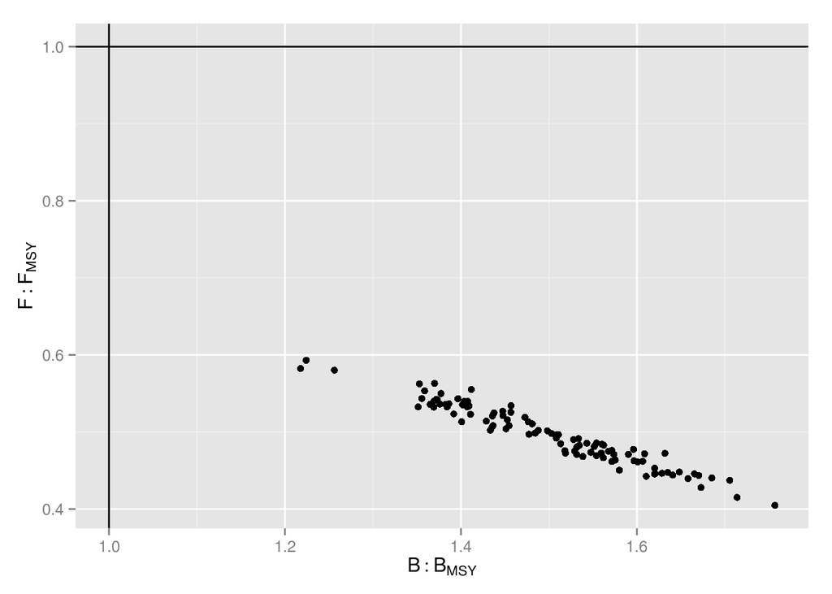

```r
ggplot(data = as.data.frame(mvrnorm(100, currentState, currentStateVar)), aes(bbmsy,
    ffmsy)) + geom_point() + geom_hline(aes(yintercept = 1)) + geom_vline(aes(xintercept = 1)) +
    xlab(expression(B:B[MSY])) + ylab(expression(F:F[MSY]))
```

# Advice Plots

```r
library(kobe)
setGeneric("kobe", function(object, method, ...) standardGeneric("kobe"))
```

```
[1] "kobe"
```

```r
source("~/Desktop/flr/pkgs/biodyn/R/biodyn-kobe.R")
```

## Marginal Density for Stock/BMSY

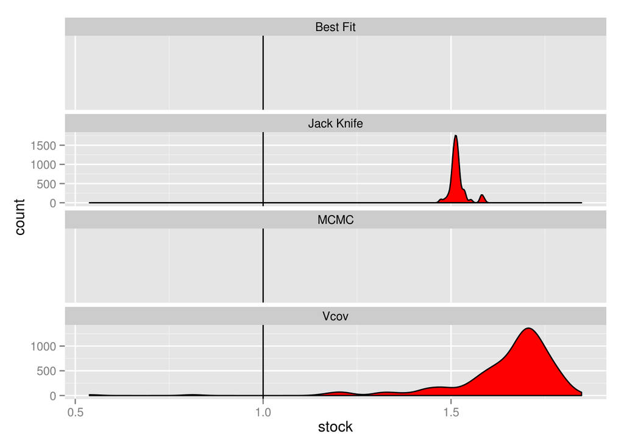

```r
df = kobe(sims)
ggplot(subset(df, year == 49)) + geom_density(aes(x = stock, y = ..count..),
    position = "stack", fill = "red") + geom_vline(aes(xintercept = 1)) + facet_wrap(~.id,
    scale = "free_y", ncol = 1)
```

```r
# scale_x_continuous(limits=c(0.5,1.5))
```

## Marginal Density for Harvest/FMSY

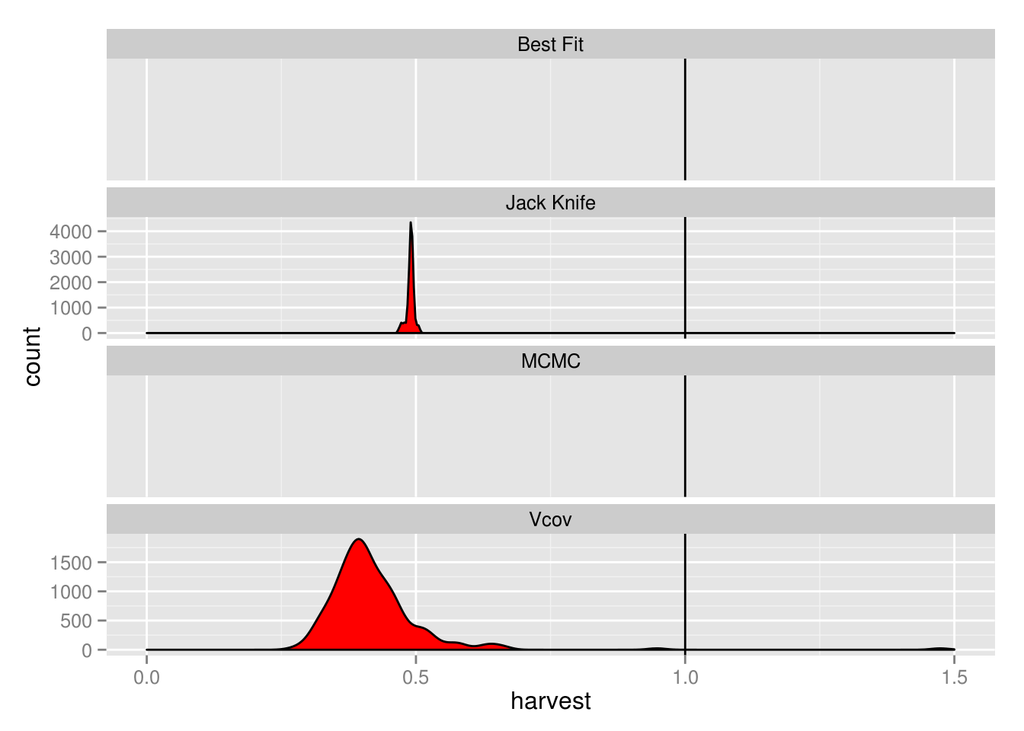

```r
ggplot(subset(df, year == 49)) + geom_density(aes(x = harvest, y = ..count..),
    position = "stack", fill = "red") + geom_vline(aes(xintercept = 1)) + facet_wrap(~.id,
    scale = "free_y", ncol = 1) + scale_x_continuous(limits = c(0, 1.5))
```

## Kobe Phase Plot

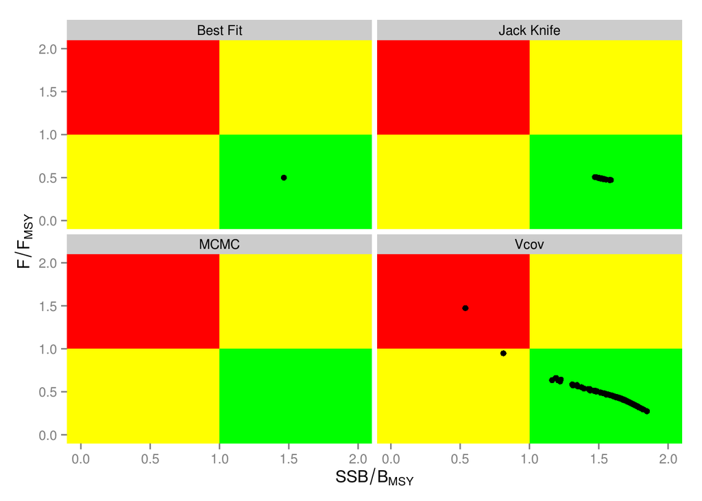

```r
library(kobe)
kobePhase() + geom_point(aes(stock, harvest), data = subset(df, year == 49)) +
    facet_wrap(~.id, ncol = 2)
```

# Projections

Once stock parameters and status has been estimated then projections need to be conducted to inform management.

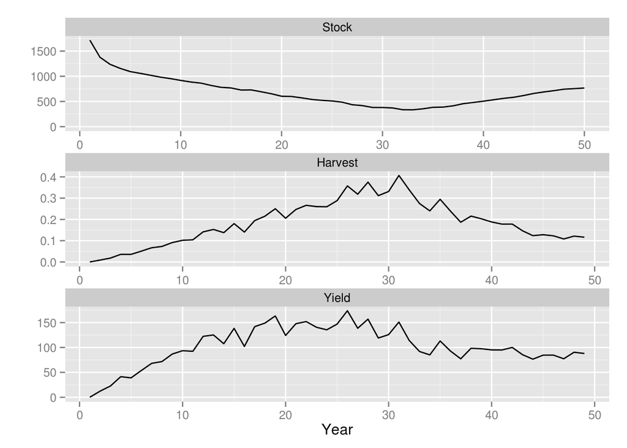

```r
harvest = rlnorm(1, log(harvest(bdHat))[, -dims(bdHat)$year], 0.1)
bdHat = fwd(bdHat, harvest = harvest)

plot(bdHat)
```

# Harvest Control Rules

Use simulated data

```r
bd = simBiodyn()
```

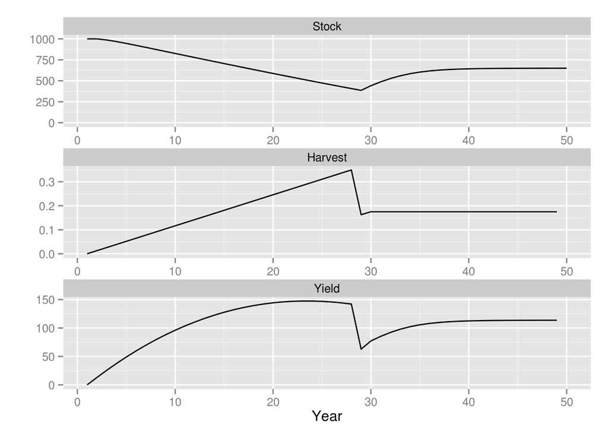

```r
## simulate HCRs, annual, tri-annula, F bound, TAC bound
bd = window(bd, end = 29)
for (i in seq(29, 49, 1)) bd = fwd(bd, harvest = hcr(bd, refYrs = i, yrs = i +
    1)$hvt)
simHCR = biodyns(`1` = bd)

plot(bd)
```

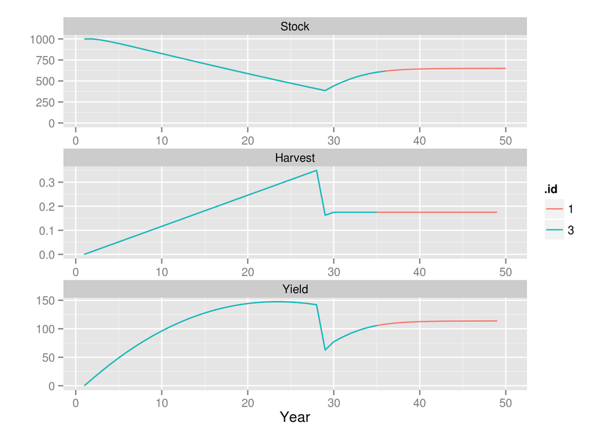

```r
bd = window(bd, end = 29)
for (i in seq(29, 49, 3)) bd = fwd(bd, harvest = hcr(bd, refYrs = i, yrs = i +
    1:3)$hvt)
simHCR[["3"]] = bd
save(simHCR, file = "/home/laurie/Desktop/sims.RData")
plot(simHCR)
```

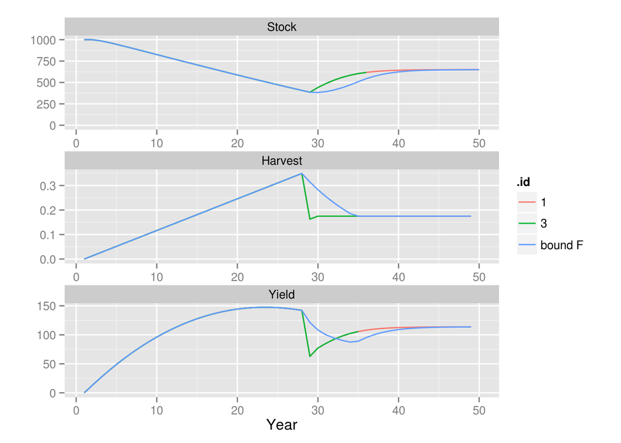

```r
bd = window(bd, end = 29)
for (i in seq(29, 49, 1)) bd = fwd(bd, harvest = hcr(bd, refYrs = i, yrs = i +
    1, bndF = c(0.9, 1.1))$hvt)
simHCR[["bound F"]] = bd

plot(simHCR)
```

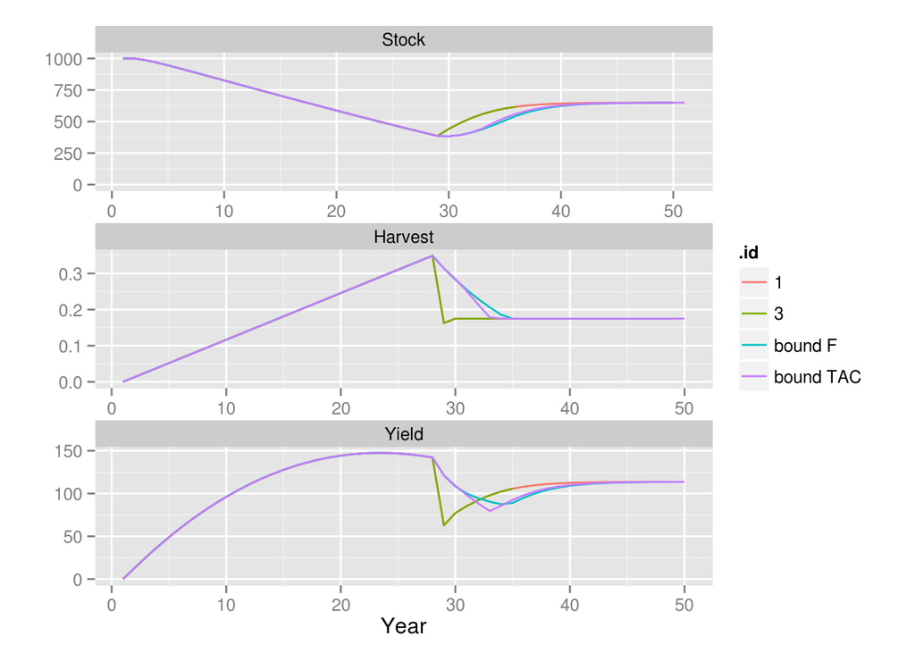

```r
bd = window(bd, end = 30)
for (i in seq(29, 49, 1)) bd = fwd(bd, catch = hcr(bd, refYrs = i, yrs = i +
    1, tac = T, bndTac = c(0.9, 1.1))$tac)
simHCR[["bound TAC"]] = bd

plot(simHCR)
```

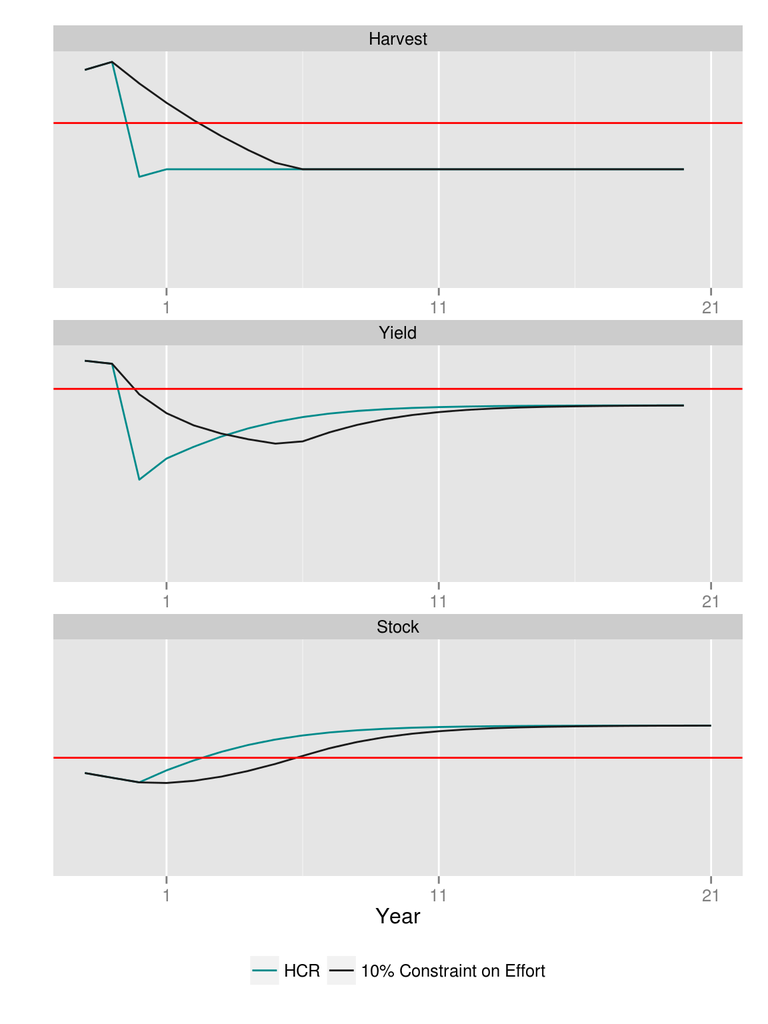

```r
p. = plot(simHCR[c(1, 3)]) + theme(legend.position = "bottom") + scale_colour_manual(values = c("cyan4",
    "grey10"), labels = c("HCR", "10% Constraint on Effort")) + guides(col = guide_legend(title = NULL)) +
    scale_x_continuous(limits = c(27, 50), breaks = c(30, 40, 50), labels = c(1,
        11, 21)) + scale_y_continuous(breaks = NULL)

p.$data = transform(p.$data, qname = factor(qname, levels = c("Harvest", "Yield",
    "Stock")))
p. + geom_hline(aes(yintercept = X1), data = cbind(qname = c("Yield", "Harvest",
    "Stock"), data.frame(refpts(bd))), col = "red")
```

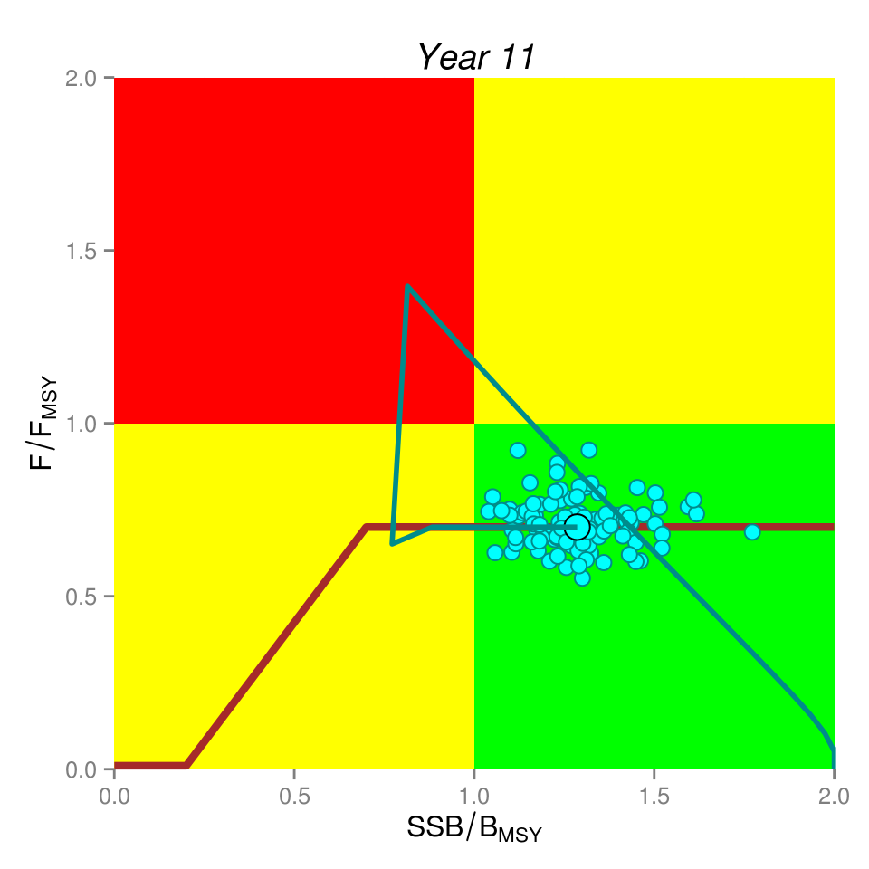

```r
kb = ldply(simHCR[c(1)], function(x, sd = 0.1) model.frame(mcf(FLQuants(stock = rlnorm(100,
    log(stock(x)%/%bmsy(x)), sd), harvest = rlnorm(100, log(harvest(x)%/%fmsy(x)),
    sd)))))
kb = subset(kb, year %in% 29:50)

pt = ldply(simHCR[c(1)], function(x) model.frame(mcf(FLQuants(stock = stock(x)%/%bmsy(x),
    harvest = harvest(x)%/%fmsy(x)))))
pt = subset(pt, year %in% 1:50)
pt. = ddply(pt, .(year, .id), with, data.frame(stock = median(stock), harvest = median(harvest)))

i = 40
print(kobePhase(subset(kb, year %in% i)) + geom_line(aes(stock, harvest), data = biodyn:::hcrPlot(bd),
    col = "brown", size = 1.5) + ggtitle(paste("Year", i - 29)) + theme(legend.position = "none",
    plot.background = element_rect(fill = "transparent", colour = NA), plot.title = element_text(lineheight = 0.8,
        face = "italic")) + xlim(0, 2) + ylim(0, 2) + geom_point(aes(stock,
    harvest, col = .id, fill = .id), shape = 21, size = 3) + geom_point(aes(stock,
    harvest, group = .id, fill = .id), col = "black", data = subset(pt., year ==
    i), shape = 21, size = 5) + geom_path(aes(stock, harvest, col = .id, group = .id),
    data = subset(pt, year <= i), size = 1) + scale_fill_manual(values = c("cyan1",
    "green", "red", "yellow")) + scale_colour_manual(values = c("cyan4", "green",
    "red", "yellow")) + coord_cartesian(xlim = c(0, 2), ylim = c(0, 2)))
```

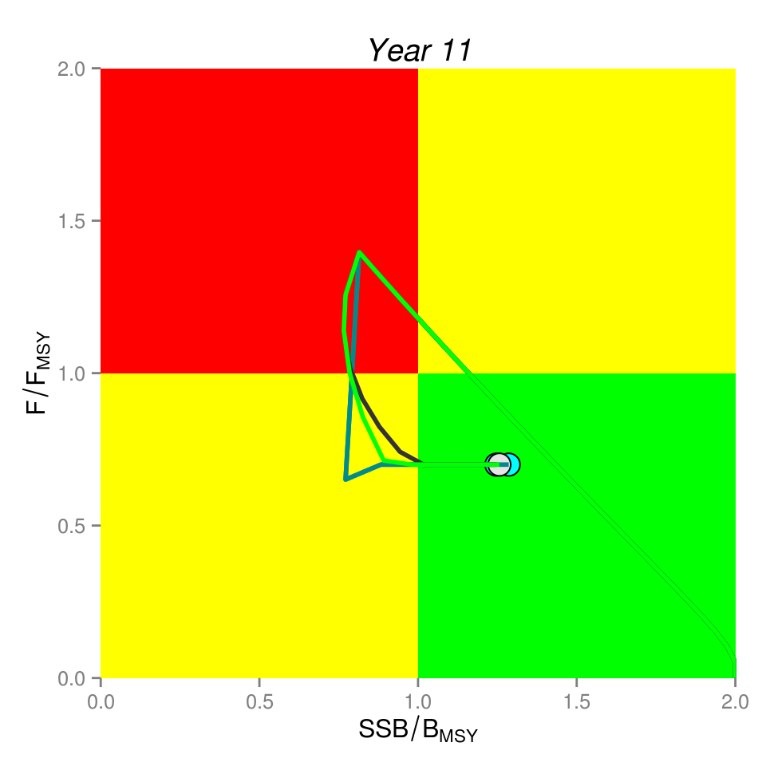

```r
library(FLCore)
library(plyr)
library(kobe)
library(ggplot2)

kb = ldply(simHCR[1:2], function(x, sd = 0.1) model.frame(mcf(FLQuants(stock = stock(x)%/%bmsy(x),
    harvest = harvest(x)%/%fmsy(x)))))
kb = subset(kb, year %in% 29:50)

pt = ldply(simHCR, function(x) model.frame(mcf(FLQuants(stock = stock(x)%/%bmsy(x),
    harvest = harvest(x)%/%fmsy(x)))))
pt = subset(pt, year %in% 1:50)
pt. = ddply(pt, .(year, .id), with, data.frame(stock = median(stock), harvest = median(harvest)))

i = 40
kobePhase(subset(kb, year %in% i)) + # geom_line(aes(stock,harvest),data=hcrPlot(bd),col='brown',size=1.5)+
ggtitle(paste("Year", i - 29)) + theme(legend.position = "none", plot.background = element_rect(fill = "transparent",
    colour = NA), plot.title = element_text(lineheight = 0.8, face = "italic")) +
    xlim(0, 2) + ylim(0, 2) + geom_point(aes(stock, harvest, col = .id, fill = .id,
    size = .id), shape = 21) + geom_point(aes(stock, harvest, fill = .id, group = .id),
    data = subset(pt., year == i), shape = 21, col = "black", size = 5) + geom_path(aes(stock,
    harvest, col = .id, group = .id), data = subset(pt, year <= i), size = 1) +
    scale_fill_manual(values = c("cyan1", "cyan1", "grey90", "green", "red",
        "yellow")) + scale_size_manual(values = c(1, 3)) + scale_colour_manual(values = c("cyan4",
    "cyan4", "grey20", "green", "red", "yellow")) + coord_cartesian(xlim = c(0,
    2), ylim = c(0, 2))
```

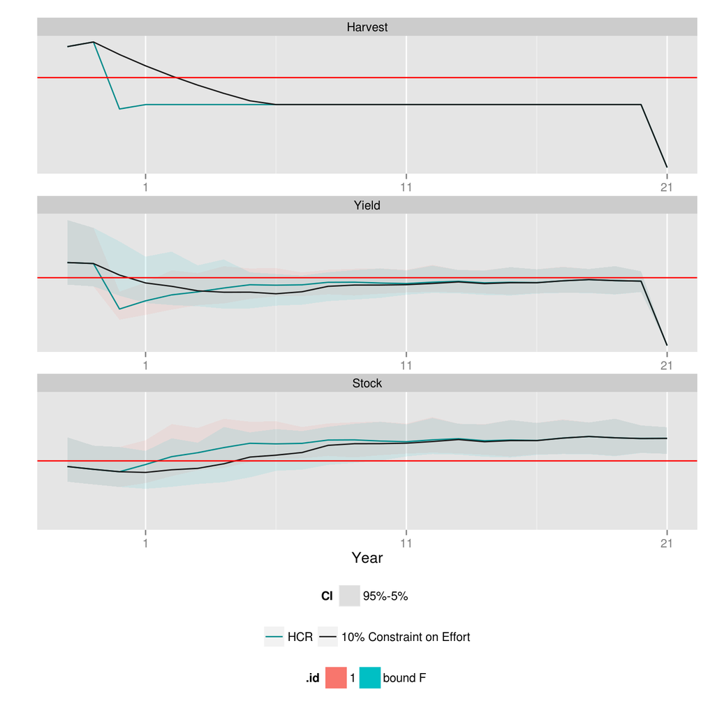

```r
pe = rlnorm(100, FLQuant(0, dimnames = list(year = 1:50)), 0.5)
simHCR[[1]] = fwd(simHCR[[1]], harvest = harvest(simHCR[[1]])[, ac(1:50)], pe = pe)
simHCR[[3]] = fwd(simHCR[[3]], harvest = harvest(simHCR[[3]])[, ac(1:50)], pe = pe)
p. = plot(simHCR[c(1, 3)]) + theme(legend.position = "bottom") + scale_colour_manual(values = c("cyan4",
    "grey10"), labels = c("HCR", "10% Constraint on Effort")) + guides(col = guide_legend(title = NULL)) +
    scale_x_continuous(limits = c(27, 50), breaks = c(30, 40, 50), labels = c(1,
        11, 21)) + scale_y_continuous(breaks = NULL)

p.$data = transform(p.$data, qname = factor(qname, levels = c("Harvest", "Yield",
    "Stock")))
p. + geom_hline(aes(yintercept = X1), data = cbind(qname = c("Yield", "Harvest",
    "Stock"), data.frame(refpts(bd))), col = "red")
```

# MSE

```r
biodyn:::mseBiodyn
```

## Full Width Figures

You can arrange for figures to span across the entire page by using the `fig.fullwidth` chunk option.

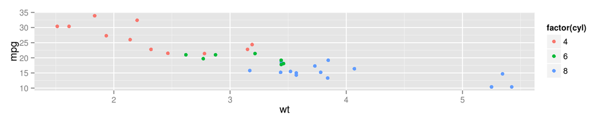

```r
qplot(wt, mpg, data = mtcars, colour = factor(cyl))
```

Note the use of the `fig.width` and `fig.height` chunk options to establish the proportions of the figure. Full width figures look much better if their height is minimized.

## Main Column Figures

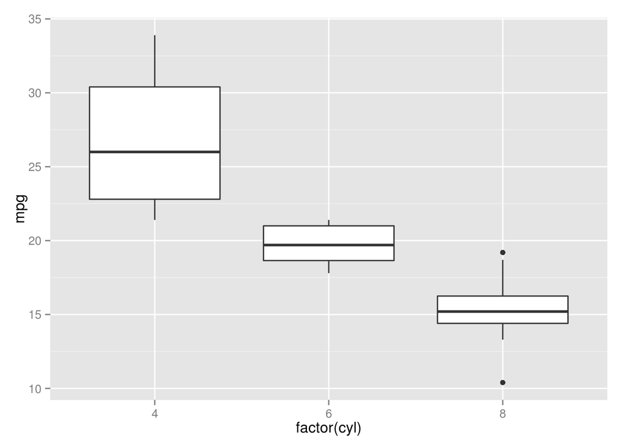

```r
qplot(factor(cyl), mpg, data = mtcars, geom = "boxplot")
```